# The Effects of Air Pollutants on Lifespan in Chicago

It’ll be interesting to see how these key variables will interact with our response variable. **(2)** Our response variable is death, which is the number of non-accidental deaths on a date. Because we will be using Poisson GAMs, we will use the log scale to examine our response variable.

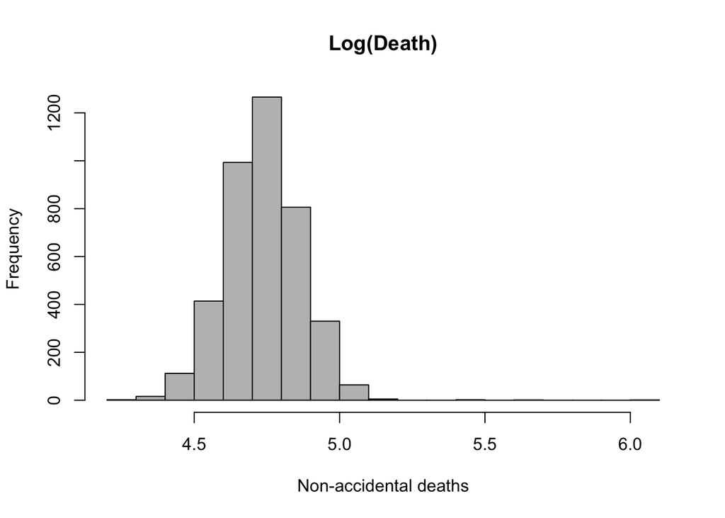

Histogram of response variable

Looking at our Figure 2, we can see that our response variable’s distribution has a normal distribution, centered around 4.7 non-accidental deaths. In addition, its summary statistics is: its minimum is 69 deaths, median is 114 deaths, the mean is 115 deaths, and the maximum is 411 deaths. Next, let’s observe how each unlagged key variable’s distribution is with death (we’ll look into the lagged versions in a little later when we compare their correlations). **(3)** The scatter plots on the next page shows that there are no clear linear relationships between each of the key variables and the response variable. Similarly to the univariate analyses, sulfur dioxide and particulate matter behave similarly with the response variable: both are centered around 0 with a few outliers. Ozone and Temperature are more spread out with also a few outliers.

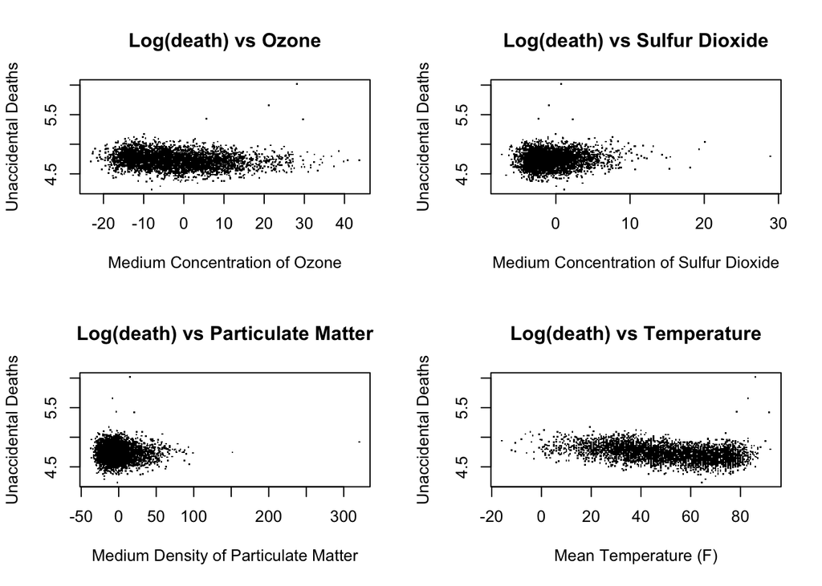

Scatter plot of response vs key variables

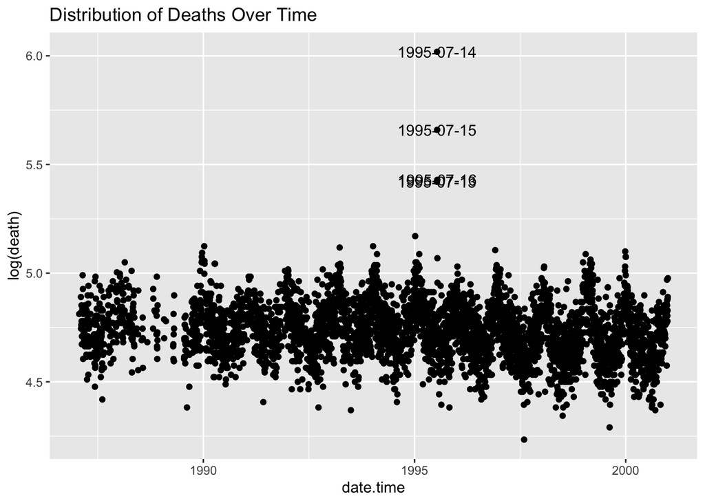

Deaths over time

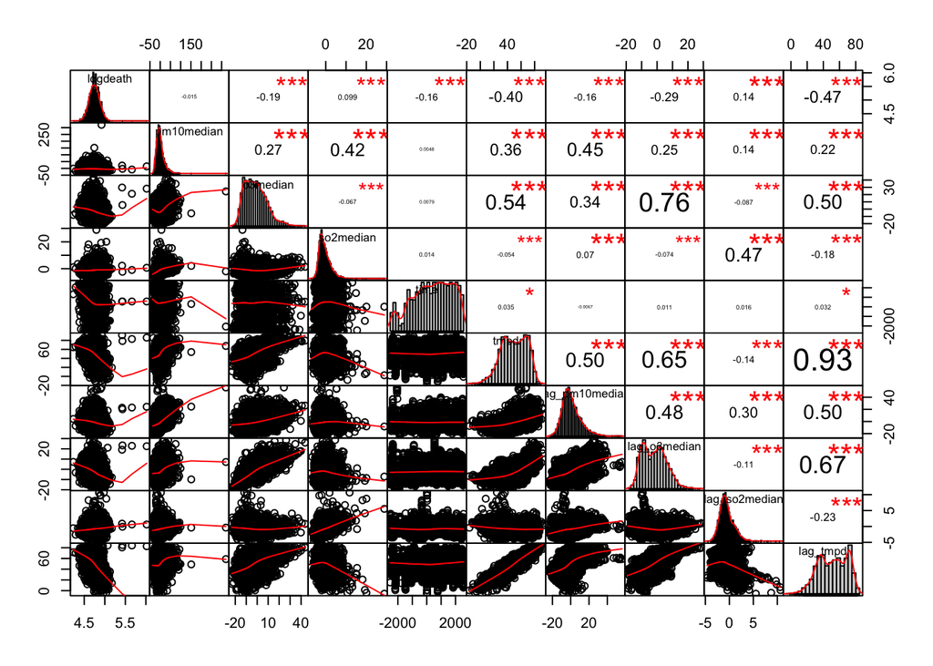

**(5)** One thing that that I found interesting is how the correlation plots showed that lagged versions of our key variables have a stronger correlation with death than the unlagged versions of our key variables. This could definitely suggest modelling decisions to make when we will try to understand air pollutants effect on human’s health and how its effect are over time.

# Modeling & Diagnostics

**(1)** Now let’s make models to see how they fit with our data. We’ll do this by fitting 2 Poisson generalized additive models to the data, one with unlagged versions of our air pollutants and other with lagged versions of our air pollutants. For simplicity of better fitting and speed reasons, we will use spline smoother terms for all variables and use 4 degrees of freedom. That way, we could potentially observe the models better.